# Mapping (A)Ideology: A Taxonomy of European Parties Using Generative LLMs as Zero-Shot Learners

Martina Chizzola

2025-04-14

# Table of Contents

- Introduction
- The Author: Riccardo di Leo
- Overview of the Paper
- Methods used
- Conclusions

## Riccardo di Leo

- Research fellow in the Department of Political and Social Sciences at the European University Institute
- Part of ERC-funded Project POSTNORM (*Post-Authoritarian Norms and the Ideological Legacy of Dictatorships*)
- Focus on the study of public opinion, with applications to the civil-military gap, terrorism in Western countries, and historical legacies

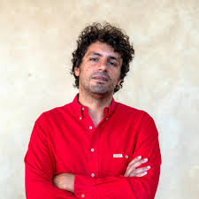

## What is the Aim of the Paper?

- Mapping of the ideological positions of European parties
- Whether advancements in Large Language Models allow social scientists to recur to unsupervised machine learning to obtain parties’ ideological positions
- Instruments used: Generative Pre-Trained Transformers

## Advantages of AI-generated data

- Reproducibility
- Agility
- Researchers can easily adjust parameters (especially using GPT-3.5)
- Produces estimates of same quality as other commonly used alternatives

## Relevance of the Paper

- First structural assessment of whether LLMs can evaluate the left-right position of European parties as *zero-shot learner*
- Only a few papers in Political Science have so far exploited GPT-3.5 as a *zero-shot learner*

# How is the Analysis Carried Out?

Creation of 9 cross-countries sub-samples of parties to capture the EU arena at the time of each EU Parliament election (1979-2019)

## To estimate ideological position

- Production of all possible pairwise party duplets in the reference year
- Ask GPT-3.5 to identify the “most right-wing” option between the two parties in a duplet
- Application of a Barry-Terry decomposition to the duplets
- Generation of an ideological ranking based on the evaluations of GTP-3.5
- Each classification is performed seven times

## Comparison of LLMs developed by AI

- GPT-4o outperforms GPT-3.5 (also outperformed by Llama-3.1) and GPT-4o mini
- GPT-4o as most expensive version

# Findings about GPT-3.5

- GPT-3.5 performs equally well when pooling reference years and when asked to estimate parties’ positions after its training period ends
- Scores are insensitive to the model setup, the framing of the task, and the ordering of the party duplets
- Responses are insensitive to randomly cutting the sample of evaluated duplets

## Conclusions

- Improved understanding of where to locate GPT-3.5 as coder
- AI can become a substitute of expert-based measure
- Confirms GPT-3.5 ability as *zero-shot* political learner
- Supports the consensus on LLM’s potential in enhancing computational social sciences
- Quality of GPT-3.5’s assessment depends upon availability of a large quantity of training data

## Main Questions of the Author

- Can GTP solve the issue of existing ideological scores registering low levels of convergent validity in longitudinal settings?
- Why does GPT5 -3.5 fail to accurately capture ideology in a dynamic setting?
- Why do some open-source LLMs perform poorly in a zero-shot learning?

# Thank You for Your Attention!

PL/CS 362